# R package

Will Koury

2020-11-18

# Introduction

Congratulations for getting this far. To complete the evidence that you have made a working R package please answer the following by using the supplied rmd and upload the knitted html to CANVAS.

I will assume your package is called **MYPAC** and you have packaged and documented functions `myf1`, `myf2`, `myf3` and `myf4`.

Your actual package name and functions will obviously be called something else.

# First function

Please place your first function in the r chunk in the following way:

Once you are ready please remove the option `eval = FALSE`

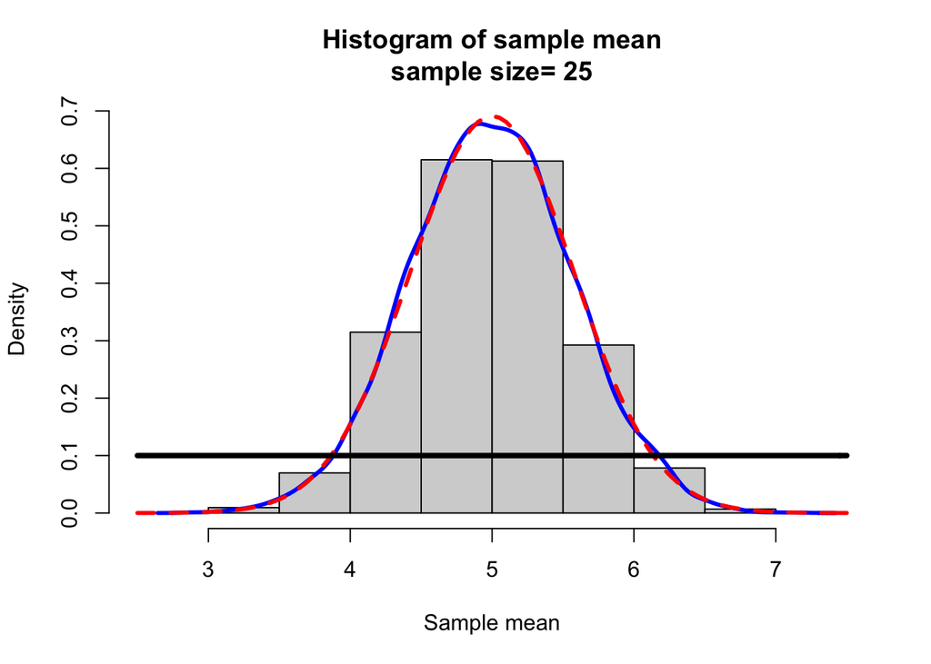

```r
math4753kouryRpackage::packagecltu(n=25,iter=10000)
```

# Second function

Please place your second function in the r chunk in the following way:

Once you are ready please remove the option `eval = FALSE`

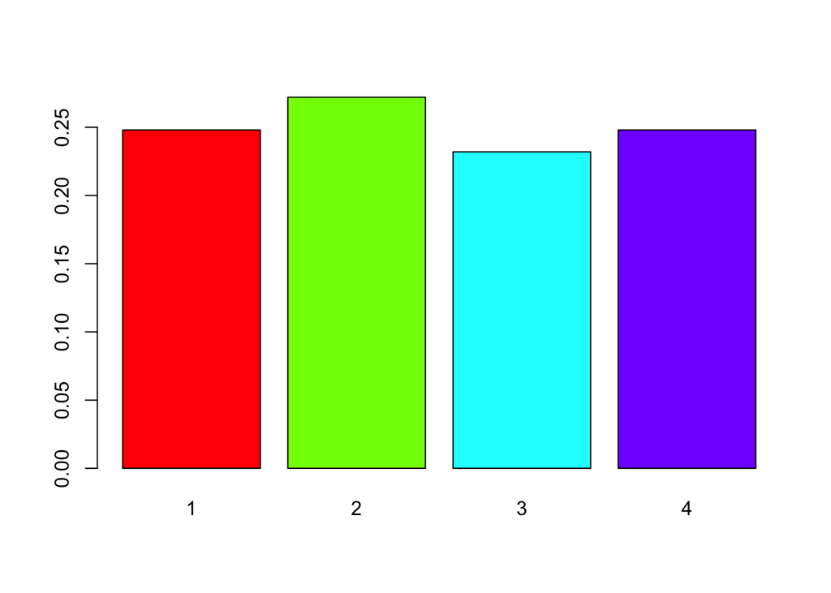

[output not shown]

[output cut: 30 more lines]

```r
math4753kouryRpackage::mymult()
```

# Third function

Please place your third function in the r chunk in the following way:

Once you are ready please remove the option `eval = FALSE`

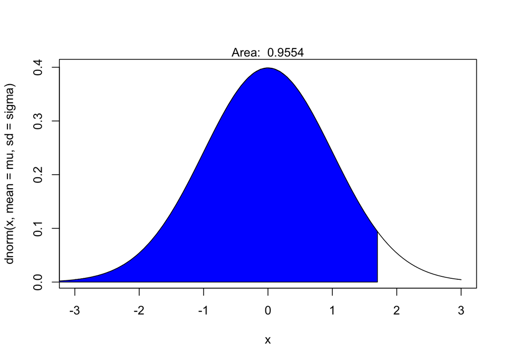

```r
math4753kouryRpackage::myncurve(mu=0,sigma=1,a=1.7)
```

# Forth function

Please place your forth function in the r chunk in the following way:

Once you are ready please remove the option `eval = FALSE`

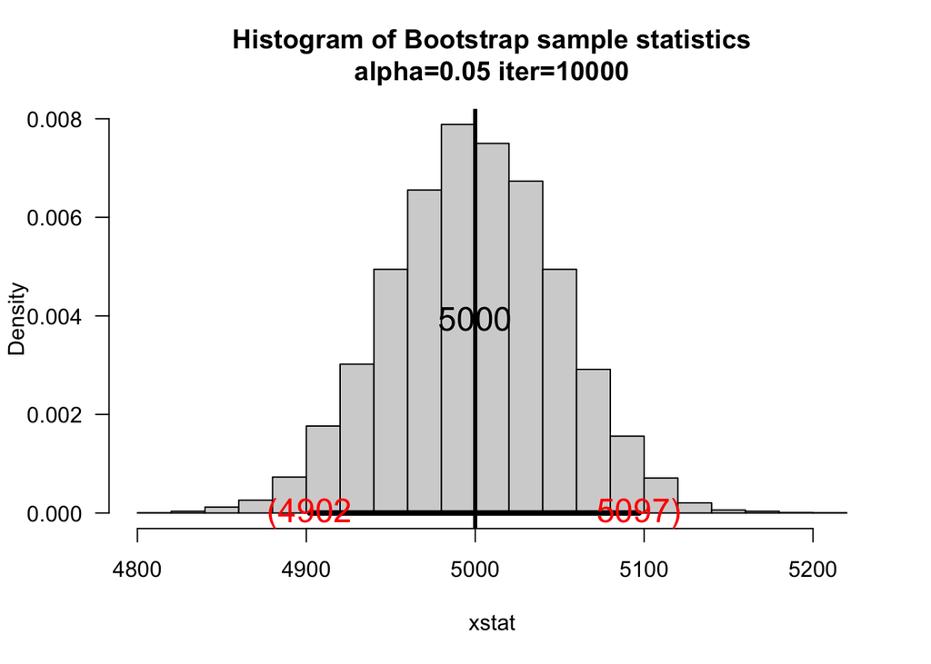

```r
math4753kouryRpackage::myboot(x=(1:9999),fun="median")
```

## Note

There are other functions from the labs. They can be found in the R folder.

# The github repository

This is the address of my GITHUB repository: https://github.com/wkoury/math4753-koury-R-package.git